# Why I hope that Statcheck is useless within one year: A case for dynamic documents

## Dynamic documents in R Markdown

**Massive disclaimer: I seriously do not know what I'm doing. I try stuff and it works at times. Please consider trying stuff too. It's fun.**

[figure not shown]

I'm serious

## Dynamic reporting in R Markdown

**Massive disclaimer: I seriously do not know what I'm doing. I try stuff and it works at times. Please consider trying stuff too. It's fun.**

[figure not shown]

Bing

## A short history

- Literate programming (Knuth, 1984)
- Dynamic documents in R (Xie, 2015)
- Sweave: Integration of R into LaTeX documents
- knitr: Sweave + RMarkdown format, caching, + other language support (Python, C++, etc.)
- knitr is backbone of R Markdown –> Focus of today

## Why should everybody document dynamically - A tripartite

1. Statistical inconsistencies are everywhere.. (Nuijten et al., 2016)
2. Reproducibility = life
3. Doing manual work in 2018 seems rather silly

## Statistical inconsistencies are everywhere

- Inconsistencies in psych: it's bad (Nuijten et al., 2016). Replication in management: same/worse (van Zelst et al., work in progress)
- Reasons are well-known: typos, copy-paste errors, incorrect rounding, etc.

Solution 1: Statcheck

- But statcheck can only read APA
- Statcheck shows where you were wrong, but doesn't fix it

## Statistical inconsistencies are everywhere (2)

Solution 2: tidystats

- R-only, although I'm not sure why this is a problem (:
- Does not yet support most analyses
- Specific output (e.g. CIs) has to be added manually

Also: tidystats solves other problems than R Markdown does

Also: use tidystats and R Markdown together (Sleegers, 2018)

## Statistical inconsistencies are everywhere (3)

R Markdown offers some encompassing solutions:

- It's not after the fact: mistakes are prevented while writing
- Supports all analyses (e.g., I managed to produce CIs in a table from meta-analytic structural equation modeling)
- If R can analyze it, R Markdown can print it

Downside:

- The good old steep learning curve

## Reproducibility = problem then, problem now

"God blessed them and said to them, "Be fruitful and reproduce" (Genesis 1:28; 9:1)

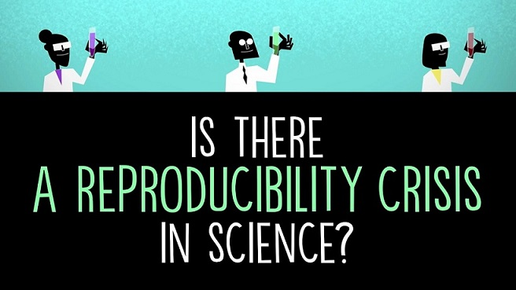

Reproducibility

## Reproducibility = life

1. Will you capable of reproducing your own results in half a year from now?
2. Will your co-authors be able to do this?
3. Will a colleague that is not a co-author?
4. An independent researcher who's in your field of expertise?

Data package requirement (mandatory!): be able to reproduce all your results in reasonable amounts of time

## Reproducibility = life (2)

Remember those methods sections where you seem to be unable to understand what the authors did?

Even if you have the syntax/code, would you be able to figure out which analysis produces which result in the paper?

## Reproducibility = life (3)

[figure not shown]

What did I just read

## Reproducibility = life (4)

Complete R Markdown file can be self-contained (including main text, data manipulation, analyses, formatting)

You **always** understand which number was produced by which analysis at the exact place in your manuscript

- Don't forget to keep annotating your code: you *will* forget what you did

## Doing manual work in 2018 seems rather silly

"we have to manually copy over statistical results into or out of a manuscript" (Sleegers, 2018)

Manual work situations that can be prevented:

- Redoing analyses when some new data came in (e.g., new papers for your meta-analysis)
- "Can you try this other statistical specification and send me the table with output?"
- "Let's submit to this other journal which has completely different formatting requirements"

That seems like a serious waste of time..

## Conclusion

Several research-process related problems:

1. Not all statistics are *correctly* reported
2. Non-reproducible research is not research –> we cannot take it seriously
3. Wasting time on non-useful actions

Dynamic documents/dynamic reporting solves this

## Some general statements about R Markdown

Able to produce:

- Word / ODT
- PDF (LaTeX)
- html / Github compatible markdown
- Slides for presentation
- Shiny documents

Can import:

- data / other R-files / 'internet' files / bib-file / csl-file

## R Markdown functionality

R Markdown integrates text (Markdown / LaTeX), data manipulation (R), analyses (R), and formatting (Markdown / LaTeX)

Data analysis workflow becomes:

1. Draft intro, theory, methods within Markdown
2. Data preparation
3. Data analysis
4. Write results using code in Markdown file
5. Format document within Markdown file
6. Print and submit!

## R Markdown functionality (2)

How does it work?

You write your normal text (similar to e.g. Word) but add 'code chunks' in your text.

Code chunks act like normal R analyses. I actually often write my code in R to try it until it works and then copy paste it to R Markdown.

When you save results to objects (like in R), you can extract the results from those objects in your main text or put them into graphs/tables.

[figure not shown]

Example

## So let's put this into practice #hoedan

Today, I will show some examples of how to build an R Markdown document, how text drafting looks and how you can insert results and other statistical output in your document.

Fasten your seatbelts.

## Creating a document

[figure not shown]

yaml header

## Write your draft

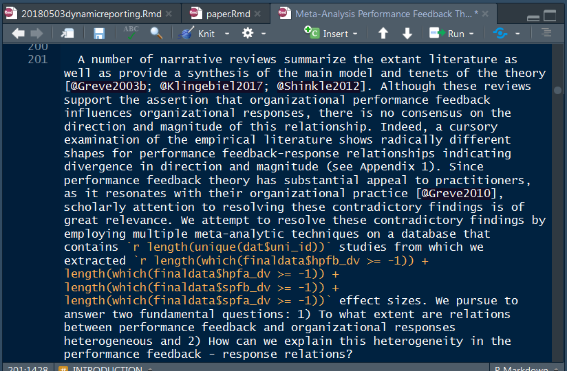

main text

## How about analyses?

We'll start with the Student's sleep data (again)

```r
res <- t.test(extra ~ group, data = sleep, var.equal = TRUE)
```

Code:

## Let's move it up a notch

We conducted a meta-analysis on organizational performance feedback which tests to what extent firms change their strategies in response to negative performance feedback.

Obviously, we wanted to test some moderators and conducted a meta-regression.

```r
spfb.wls <- rma(spfb , mods=~ public + finance*mean_age + service +
                hightech  + change + search, var, method="DL",
                data=dat, test="knha")
res.spfb <- list(spfb.wls)
```

## Writing the results section

Code:

```r
# For social performance feedback, we find that firms are significantly
# more responsive to non-financial performance feedback below the
# aspiration level ($\beta$ = ` round(spfb.wls$b[3],3)`,
# *p*-value = ` round(spfb.wls$pval[3],3)`).
```

Produces:

For social performance feedback, we find that firms are significantly more responsive to non-financial performance feedback below the aspiration level (\(\beta\) = -0.081, *p*-value = 0.019).

## Producing table

Let's say you also want to produce a table with the results.

knitr allows for easy table production, *if* you can configure your code right (this will take (many) trial and error runs)

```
      knitr::kable(data.frame(name=c("Constant","Public firm","Finance",
      "Firm age","Service","High-tech","Change","Search","Interaction MetricAge"),

      HPFBA = sapply(res.spfb, function(x) x`$`b),
      CIlb = sapply(res.spfb, function(x) x`$`ci.lb),
      CIub = sapply(res.spfb, function(x) x`$`ci.ub),
      Pvalue=sapply(res.spfb, function(x) x`$`pval),
      digits=3,  col.names=c("Variable","PF < HA","CI~lb~","CI~ub~",
                              "*p-value*"),
      caption = "Table 3: Meta-analytic weighted
       least squares for social performance feedback")
```

## Table time

Table 3: Meta-analytic weighted least squares for social performance feedback

[output not shown]

So we wanted to plot some meta-analytic interaction. We interact our 'performance metric' variable with 'organizational age'.

```r
require(metafor)
dat$spfb <-0.5*log((1+dat$spfb_dv)/(1-dat$spfb_dv))
spfb.wls <- rma(spfb,mods=~ public + finance*mean_age + service +
                  hightech + search + change,var,data=dat,
                method="DL",test="knha")
wi    <- 1/sqrt(dat$var)
size  <- 0.5 + 1.5*(wi - min(wi))/(max(wi) - min(wi))
plot(dat$mean_age, dat$spfb_dv, pch=19, xlim=c(0,120), ylim=c(-0.5,0.5), cex=size,
     xlab="Firm age (years)", ylab="Correlation", las = 1, bty="l")
preds.nonfinance <- predict(spfb.wls, newmods=cbind(1,0,0:120,0,0,0,0,0))
lines(0:120, preds.nonfinance$pred,col="red",lwd=2)
lines(0:120, preds.nonfinance$ci.lb,lty="dotted",col="red",lwd=2)
lines(0:120, preds.nonfinance$ci.ub,lty="dotted",col="red",lwd=2)
preds.finance <- predict(spfb.wls, newmods=cbind(1,1,0:120,0,0,0,0,0:120))
lines(0:120, preds.finance$pred,col="blue",lwd=2)
lines(0:120, preds.finance$ci.lb,lty="dotted",col="blue",lwd=2)
lines(0:120, preds.finance$ci.ub,lty="dotted",col="blue",lwd=2)
legend("topright", legend=c("Non-financial","Financial"),lty=c("dotted","solid"),col=c("red","blue"),lwd=2)
title("P < SA for public")
```

## Plot

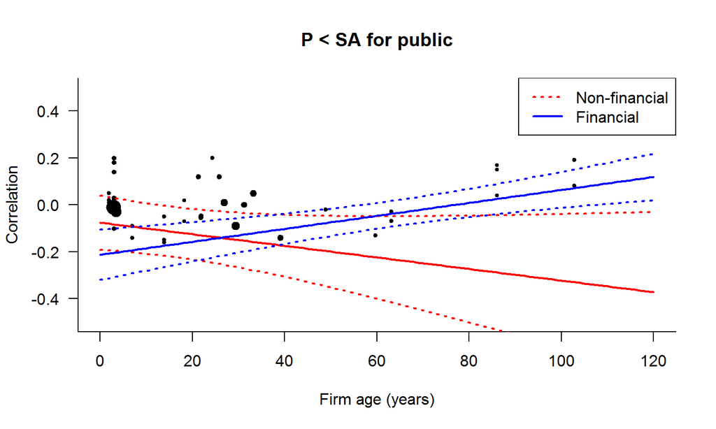

## Reporting statistics

Because all statistics are structured in a manner you devised, it is very easy to write functions that return *whatever-style* output.

Using code inside your text allows you to specify where you want statistical output, which can be individual tests, tables, graphs, etc.

## Self-contained files

Being smart with packages allows you to make a completely self-contained paper within your Rmd file

```r
if(!require(devtools)){install.packages("devtools")}
require(devtools)
if(!require(osfr)){install_github("chartgerink/osfr",force=TRUE)}
require(osfr)
download_files('bj786', private=TRUE) #masterdata.csv
download_files('wqyz2', private=TRUE) #reference file for formatting
download_files('pz3kx', private=TRUE) #20170711studies.csv
download_files('3v9jf', private=TRUE) #csl file for AMR references
download_files('g6xur', private=TRUE) #references
```

Live example from a conference paper

## Limitations of R Markdown

The pesky learning curve:

- Producing a text file with numbers: rather easy
- Producing a formatted docx/PDF with tables: doable'ish
- Producing a presentation with analyses, tables, that is nicely formatted: ????

For PhD students:

- "My supervisor doesn't understand this"

## Concluding thoughts

I think reproduciblity is a daily process. Reproducible research starts today; not when your project is done.

When the TSB Science Committee requests to check your paper, you should be able to send them what they request within five minutes.

R Markdown is a great tool to help you do that.